# Partitioning Variance: The Unconditional Model and ICC

- Show All Code
- Hide All Code
- View Source

Author

Justin Jones

Published

March 31, 2026

# 1 Introduction: The Null Model as a Starting Point

Before we add any predictors, we need to understand the fundamental question: **How much variation in our outcome exists between groups versus within groups?**

This is not a trivial question. Imagine you’re studying job satisfaction in an organization. If 80% of the variance is between teams and only 20% is within teams, then the key to understanding satisfaction lies in team-level characteristics: leadership, resources, team climate. Conversely, if 80% is within teams and 20% is between, then individual differences matter far more than team membership.

This proportioning of variance is the job of the **unconditional model** (also called the **null model**). It’s the simplest multilevel model: no predictors, just random intercepts. Despite its simplicity, it answers one of the most important questions in multilevel research: **Is there meaningful clustering in the data?**

The unconditional model is your starting point for all multilevel analyses. It provides:

1. A baseline understanding of variance structure
2. The **Intraclass Correlation Coefficient (ICC)**, which quantifies how much clustering exists
3. A reference point for calculating **pseudo-R²** values when you add predictors later
4. Evidence for whether MLM is even necessary (if ICC is near zero, ordinary regression may suffice)

Let’s build this model step by step, using the same organizational dataset we created last week.

# 2 The Unconditional Model in Words and Symbols

The unconditional model is written as:

$$Y_{ij} = \gamma_{00} + u_{0j} + r_{ij}$$

Let’s unpack this notation carefully, because multilevel models can look intimidating at first:

- **$Y_{ij}$**: The outcome for individual $i$ nested within group $j$. In our case, job satisfaction for employee $i$ in team $j$.
- **$\gamma_{00}$** (pronounced “gamma double-zero”): The grand mean, the overall intercept averaged across all groups. This is the predicted satisfaction for the “average” employee in the “average” team. It’s analogous to the intercept in OLS, but with a special notation to indicate it’s a fixed effect estimated at the group level.
- **$u_{0j}$** (pronounced “u naught j”): The random intercept deviation for group $j$. This captures how much team $j$ deviates from the grand mean. If team 5 has $u_{05} = 0.8$, then employees in team 5 are, on average, 0.8 units higher in satisfaction than the grand mean. These random intercepts are assumed to be normally distributed with mean 0 and variance $\tau_{00}^2$ (tau). The subscript “0” reminds us this is a random variation in the intercept.
- **$r_{ij}$** (pronounced “r i j”): The individual-level residual, the deviation of person $i$ from their team’s intercept. This is the variation among individuals *within* the same team. These residuals are assumed to be normally distributed with mean 0 and variance $\sigma^2$ (sigma-squared). This variance is also called the “level-1 residual variance.”

In words: **The outcome for each person equals the overall average, plus their team’s deviation from that average, plus their individual deviation from their team’s average.**

The two variance components are:

- **$\tau_{00}^2$**: Between-group variance (Level 2). How much teams differ from each other.
- **$\sigma^2$**: Within-group variance (Level 1). How much individuals within the same team differ from each other.

# 3 Fitting the Unconditional Model in R

Let’s fit this model using the `lmer()` function from the `lme4` package, using the same employee dataset we created in Week 1.

```r
set.seed(1234)
library(tidyverse)
library(lme4)
library(lmerTest)
library(performance)
library(magrittr)

# Recreate the employee dataset from Week 1
n_teams <- 50
teams <- tibble(
  team_id = 1:n_teams,
  team_size = sample(8:15, n_teams, replace = TRUE),
  team_climate = rnorm(n_teams, mean = 5, sd = 0.8))

teams %<>%
  mutate(team_climate = pmin(pmax(team_climate, 1), 7))

employees <- teams %>%
  slice(rep(1:n_teams, teams$team_size)) %>%
  arrange(team_id) %>%
  group_by(team_id) %>%
  mutate(
    emp_id = row_number(),
    employee_id = paste0("T", team_id, "E", emp_id),
    autonomy = rnorm(n(), mean = 4.5, sd = 1.2),
    autonomy = pmin(pmax(autonomy, 1), 7),
    performance = rnorm(n(), mean = 6, sd = 1.5),
    performance = pmin(pmax(performance, 1), 10),
    tenure = rgamma(n(), shape = 3, rate = 0.8)
  ) %>%
  ungroup()

employees <- employees %>%
  group_by(team_id) %>%
  mutate(
    u0j = rnorm(1, mean = 0, sd = sqrt(0.6)),
    job_satisfaction = 3.0 +
                       0.5 * scale(autonomy)[,1] +
                       0.4 * team_climate +
                       u0j +
                       rnorm(n(), mean = 0, sd = sqrt(0.8)),
    job_satisfaction = pmin(pmax(job_satisfaction, 1), 7)
  ) %>%
  ungroup() %>%
  select(-u0j, -emp_id)

cat("Dataset ready: ", nrow(employees), "employees in", n_distinct(employees$team_id), "teams\n")
```

```
Dataset ready:  604 employees in 50 teams
```

Now, fit the unconditional model:

```r
# Fit the unconditional model (null model)
model_unconditional <- lmer(job_satisfaction ~ 1 + (1 | team_id), data = employees)

# Display the summary
summary(model_unconditional)
```

```
Linear mixed model fit by REML. t-tests use Satterthwaite's method [
lmerModLmerTest]
Formula: job_satisfaction ~ 1 + (1 | team_id)
   Data: employees

REML criterion at convergence: 1748

Scaled residuals:
     Min       1Q   Median       3Q      Max
-2.44402 -0.68694 -0.01522  0.65205  2.84687

Random effects:
 Groups   Name        Variance Std.Dev.
 team_id  (Intercept) 0.6906   0.8310
 Residual             0.8690   0.9322
Number of obs: 604, groups:  team_id, 50

Fixed effects:
            Estimate Std. Error      df t value Pr(>|t|)
(Intercept)   4.8978     0.1237 49.0303   39.61   <2e-16 ***
---
Signif. codes:  0 '***' 0.001 '**' 0.01 '*' 0.05 '.' 0.1 ' ' 1
```

Let’s dissect this output:

## 3.1 Interpreting the Variance Components

# 4 Extracting Variance Components and Computing the ICC

The **Intraclass Correlation Coefficient (ICC)** quantifies the degree of clustering. It answers: “How much do observations within the same group correlate with each other?”

The ICC is calculated as:

$$ICC = \frac{\tau_{00}^2}{\tau_{00}^2 + \sigma^2}$$

This is simply the proportion of total variance that is at the group level. Let’s compute it several ways:

```r
# Method 1: Manual calculation from variance components
tau_sq <- 0.580
sigma_sq <- 0.794
icc_manual <- tau_sq / (tau_sq + sigma_sq)

cat("ICC (manual calculation):", round(icc_manual, 3), "\n")
```

```
ICC (manual calculation): 0.422
```

```r
# Method 2: Extract variance components using VarCorr()
var_components <- VarCorr(model_unconditional)
print(var_components)
```

```
 Groups   Name        Std.Dev.
 team_id  (Intercept) 0.83102
 Residual             0.93218
```

```r
# Method 3: Using performance::icc() function
icc_performance <- icc(model_unconditional)
print(icc_performance)
```

```
# Intraclass Correlation Coefficient

    Adjusted ICC: 0.443
  Unadjusted ICC: 0.443
```

In general, ICC values of: - **< 0.05**: Negligible clustering; OLS may be sufficient - **0.05–0.10**: Small clustering; MLM is recommended but effect is modest - **0.10–0.20**: Moderate clustering; MLM is clearly warranted - **> 0.20**: Substantial clustering; MLM is essential

# 5 Design Effects: When Is MLM Worth the Complexity?

The **Design Effect (DEFF)** tells us how much the effective sample size is reduced due to clustering. It’s calculated as:

$$DEFF = 1 + (n_{0} - 1) \times ICC$$

where $n_0$ is the average group size.

```r
# Calculate DEFF
n_per_group <- nrow(employees) / n_distinct(employees$team_id)
icc_value <- icc_manual
deff <- 1 + (n_per_group - 1) * icc_value

cat("Average group size:", round(n_per_group, 1), "\n")
```

```
Average group size: 12.1
```

```r
cat("ICC:", round(icc_value, 3), "\n")
```

```
ICC: 0.422
```

```r
cat("Design Effect:", round(deff, 2), "\n")
```

```
Design Effect: 5.68
```

```r
cat("\nInterpretation: With DEFF =", round(deff, 2),
    ", the effective sample size for testing\n")
```

```
Interpretation: With DEFF = 5.68 , the effective sample size for testing
```

```r
cat("a fixed effect is", round(500 / deff, 0),
    "instead of 500.\n")
```

[output not shown]

```r
cat("That's a loss of", round(100 * (1 - 1/deff), 1),
    "% of the sample.\n")
```

```
That's a loss of 82.4 % of the sample.
```

# 6 Caterpillar Plots: Visualizing Random Intercepts

The random intercepts ($u_{0j}$ values) tell us the deviation of each team from the grand mean. We can extract these and visualize them with a “caterpillar plot”:

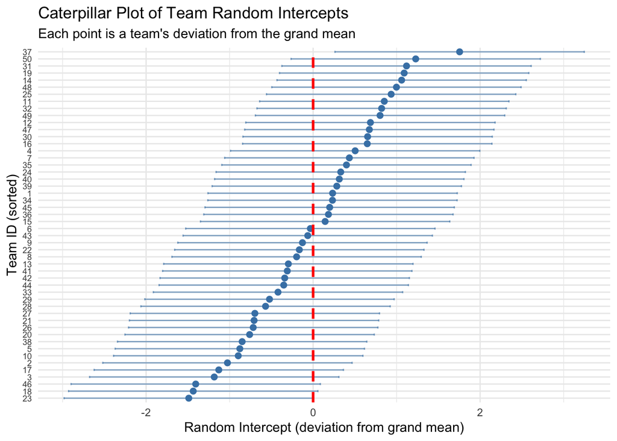

```r
# Extract random intercepts
random_ints <- ranef(model_unconditional)$team_id %>%
  rownames_to_column(var = "team_id") %>%
  rename(intercept = `(Intercept)`)

# Calculate confidence intervals for intercepts
# The SE of a random intercept is approximately sqrt(tau_sq)
se_intercept <- sqrt(0.580)

random_ints <- random_ints %>%
  mutate(
    team_id = as.numeric(team_id),
    ci_lower = intercept - 1.96 * se_intercept,
    ci_upper = intercept + 1.96 * se_intercept
  ) %>%
  arrange(intercept)

# Caterpillar plot
ggplot(random_ints, aes(x = reorder(team_id, intercept), y = intercept)) +
  geom_point(size = 2, color = "steelblue") +
  geom_errorbar(aes(ymin = ci_lower, ymax = ci_upper),
                width = 0.3, color = "steelblue", alpha = 0.6) +
  geom_hline(yintercept = 0, linetype = "dashed", color = "red", size = 1) +
  coord_flip() +
  labs(
    title = "Caterpillar Plot of Team Random Intercepts",
    subtitle = "Each point is a team's deviation from the grand mean",
    x = "Team ID (sorted)",
    y = "Random Intercept (deviation from grand mean)"
  ) +
  theme_minimal() +
  theme(axis.text.y = element_text(size = 7))
```

This caterpillar plot shows each team’s estimated intercept (deviation from the grand mean) along with its confidence interval. Teams with points above the dashed red line (at zero) have above-average job satisfaction; those below have below-average satisfaction.